# 開放科學時代：圖書資訊管理者的角色與貢獻

## 自我介紹

陳紹慶  
慈濟大學人類發展與心理學系專任副教授

開放科學中心大使  
scchen.com

## Recommended Resrouce

[FOSTER project](https://www.fosteropenscience.eu/foster-taxonomy/open-science)

[Center for Open Science](https://cos.io/)

# Educational Resource for Open Science

## Open Science Terminology

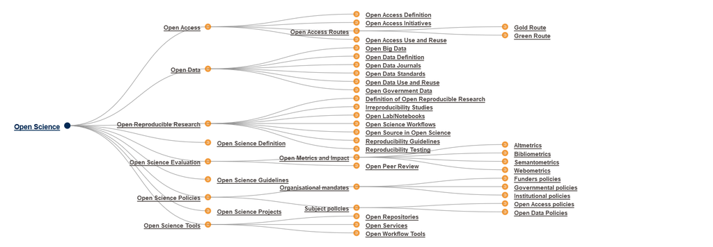

## [Learning Paths](https://www.fosteropenscience.eu/)

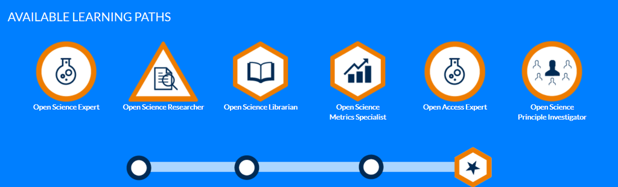

## [Open Science MOOC](https://opensciencemooc.eu/)

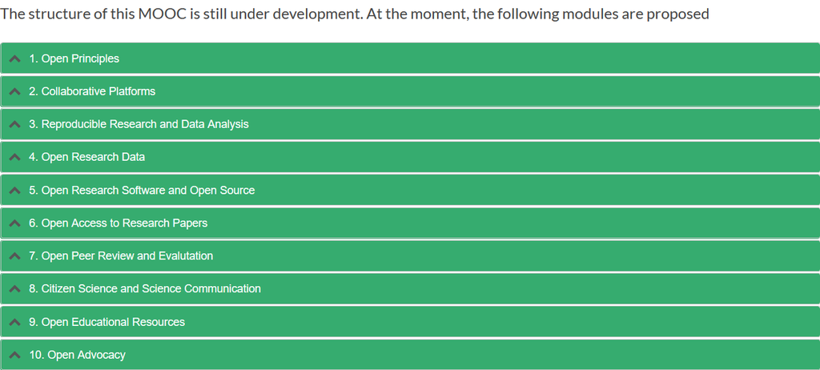

[Open Science Training book](https://tinyurl.com/osth-2018)

[Open Science at the Core of Libraries](https://www.fosteropenscience.eu/learning/open-science-at-the-core-of-libraries/#/id/5a01e2d1c2af651d1e3b1b3c)

## Before we learn what is Open Science

**Science** is the process approaching truth, but “*scientific knowledge is a product of social collaboration and its ownership belongs to the community.*”

**Scientifice knowledge** is “*original scientific research results, raw data and metadata, source materials, digital representations of pictorial and graphical materials and scholarly multimedia material*”(Berlin Declaration, 2010)

# What is open science

“*a **new approach to the scientific process** based on cooperative work and new ways of diffusing knowledge by using digital technologies and new collaborative tools*”([European Commission, 2016b:33](https://www.fosteropenscience.eu/node/1431#ec2016b))

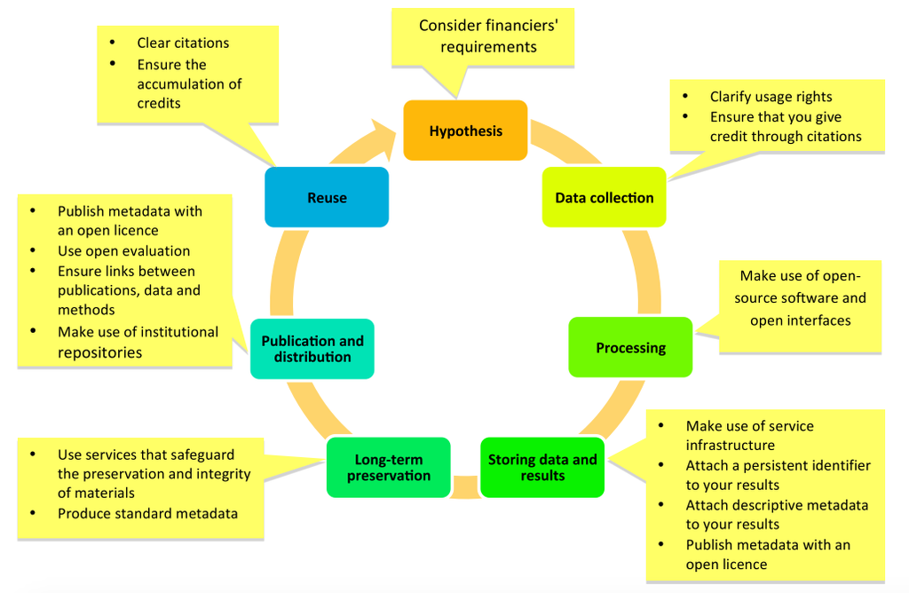

“*to make the primary outputs of publicly funded research results – publications and the research data – publicly accessible in digital format with no or minimal restriction”* ([OECD, 2015:7](https://www.fosteropenscience.eu/node/1431#oecd2015))

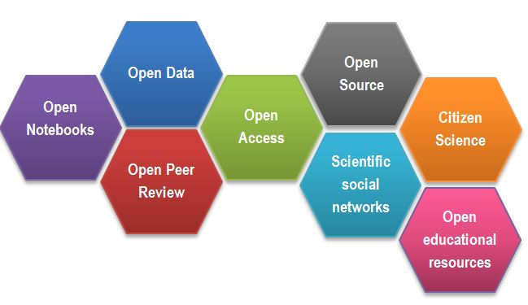

“*Even though, especially for the library and information domain, the focus is usually placed on two of these movements: **Open Research Data** and **Open Access to scientific publications***”

## Five Open Science schools of thought (Fecher and Friesike, 2014)

[figure not shown]

- *The infrastructure school concerned with the technological architecture.* (Manage research materials and data in accessible reporsitory)
- *The public school concerned with the accessibility of knowledge creation.* (Policy encourages open science practices)
- *The measurement school concerned with alternative impact measurement.* (Alternative IF reveals the contribution)
- *The democratic school concerned with access to knowledge.* (Share the values through education)
- *The pragmatic school concerned with collaborative research.* (Promote a culture of open science)

# What are the benefits of Open Science?

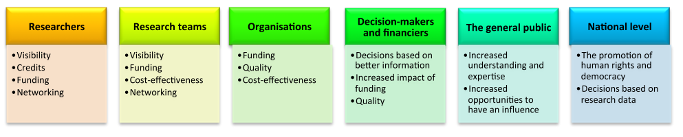

## Supportive Factors for Developing Sciences[(OECD, 2015:18)](https://www.fosteropenscience.eu/node/1431#oecd2015)

- **Efficiency**
- **Quality and integrity** [Check the Economist](https://www.economist.com/news/science-and-technology/21738872-myth-according-latest-investigation-are-research-papers-less)
- **Economic benefits**
- **Innovation and knowledge transfer**
- **Public disclosure and engagement**
- **Global benefits**

# What are the challenges for Open Science?

## Challenges

- **Socio-cultural** … researchers’ concern: benefits for competitors
- **Technological** … transparent workflow? My blog posts about [registered reports](http://scchen.com/zh/post/text_2017002/) and [academic journals](http://scchen.com/zh/post/first-chinese-rr-journal/)
- **Political** … no supportive policy
- **Organisational** … institutional deterrent over individual incentive
- **Economic** … short of funding, highly charaged OA fee
- **Legal** … Copyright issue

## Boundaries([The Royal Society, 2012:44)](https://www.fosteropenscience.eu/node/1431#royal)

- **Commercial interests and economic benefits**
  - *Data ownership and the exercise of Intellectual Property rights*
  - *Public-private partnerships*
  - *Opening up commercial information in the public interest*
- **Privacy**
- **Security and safety**

## Strategies ([European Commission, 2016b:45)](https://www.fosteropenscience.eu/node/1431#ec2016b)

**4 levels:** **people** -> **infrastructure** -> **policies** -> **economic investment**

1. **Fostering and creating incentives for Open Science**: Ph.D program for the imrpovement of research qualit`
2. **Removing barriers to Open Science**
3. **Open access policies**
4. **Developing research infrastructures for Open Science**: [DataWiz](https://datawiz.zpid.de/)
5. **Embedding Open Science in society as a socio-economic driver**: Build bridges to citizen science

## Open Access Definition

“*free access to scientific knowledge for everybody*”([Sitek and Bertelmann, 2014](http://book.openingscience.org.s3-website-eu-west-1.amazonaws.com/tools/open_access_state_of_the_art.html))

## Open Access Routes

[figure not shown]

## What is Preprint?

This is **postpreprint**! (From Airiti Library)

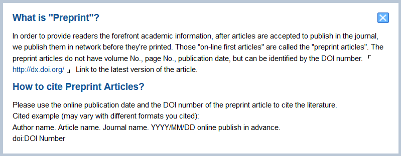

This is **preprint**!([Oransky and Marcus, 2016](https://www.statnews.com/2016/05/27/preprint-biology-bioxriv/))

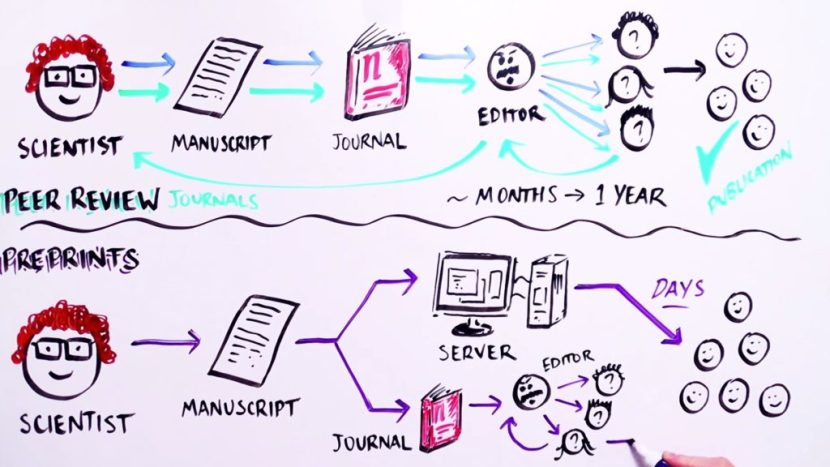

## Preprint service

[figure not shown]

## Create your preprint in OSF

[figure not shown]

[中國科學院預發佈論文發表平台](http://chinaxiv.org/home.htm); [ChinaAxiv簡介](http://chinaxiv.org/user/help.htm;jsessionid=7FED8C0DCFB7FA5BA98A13B6E46A4707); [ChinaAxiv新聞](http://chinaxiv.org/newsdetail.htm;jsessionid=7FED8C0DCFB7FA5BA98A13B6E46A4707?id=38)

2018/2/2

## How open is a journal?

[SHERPA/Romeo](http://www.sherpa.ac.uk/romeo)

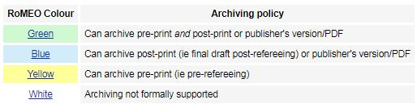

## Question for you

How would you advocate the awareness and benefits of OA in your institute?

## Show me Open Data

[figure not shown]

## Remake of OSC(2015).

Source data: https://osf.io/fgjvw/

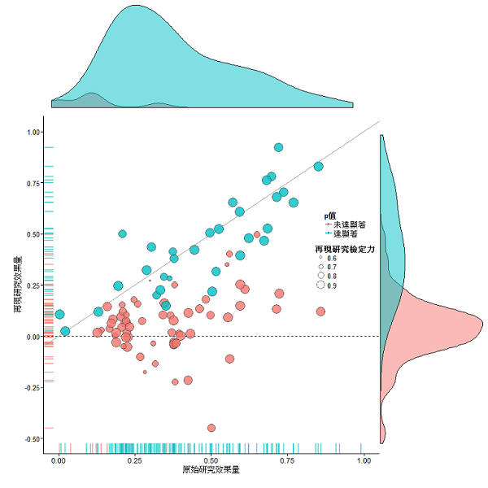

```
# Widonws系統要安裝devtools套件前，請先下載安裝對應版本的Rtools(https://cran.r-project.org/bin/windows/Rtools/)。例如安裝的R版本是3.1.3，要安裝Rtools32.exe；安裝的R版本是3.2.2，要安裝Rtools33.exe。

library(devtools)
source("../Materials/RP.P/C-3PR.R")  # 原始程式碼含兩個多位元組字符 \u2717 and \u03C1 ,此版本已置換為unicode
in.IT(c('ggplot2','grid','RColorBrewer','lattice','gridExtra','plyr','dplyr','httr'))  # 增加grid套件，確保ggplot繪圖正常
  RPPdata<-read.csv('../Materials/RP.P/rpp_data.csv',stringsAsFactors=F )  # 原始資料檔的欄位(BF,94)有多位元組字符，讀取後造成資料欄位錯置，此下載版已修正
  RPPdata<-df.Clean(RPPdata)
  RPPdata<-RPPdata$df

# Get ggplot2 themes predefined in C-3PR
mytheme <- gg.theme("clean")

##############
RPPdata$Power.Rn <- as.numeric(RPPdata$Power.R)

# Setup some variables
RPPdata$oriSig <- "未達顯著"
# 3 studies claimed an effect at .05 < p < .06
RPPdata$oriSig[RPPdata$T.pval.USE.O<=.06] <- "達顯著"
RPPdata$oriSig <- factor(RPPdata$oriSig)

RPPdata$repSig <- "未達顯著"
RPPdata$repSig[RPPdata$T.pval.USE.R<=.05] <- "達顯著"
RPPdata$repSig <- factor(RPPdata$repSig)
RPPdata$repSig <- factor(RPPdata$repSig)

# Create a scatterplot with density margin plots

# The plotHolder() function from C-3PR creates a blank plot template that will hold the figures
blankPlot <- plotHolder()

# X margin density plot (note: gg.theme() from C-3PR can be used directly in a ggplot2() call)
xDense <- ggplot(RPPdata, aes(x=T.r.O, fill=oriSig)) +
  geom_density(aes(y= ..count..),trim=F,alpha=.5) +
  xlab("") + ylab("") + xlim(0,1) +
  gg.theme("noax") +
  theme(legend.position = "none",plot.margin = unit(c(0,0,0,4), "lines"))

## Uncomment to save subplot
# ggsave("RPP_F3_xDense.png",plot=xDense)

# Y margin density plot (note: gg.theme() from C-3PR can be used directly in a ggplot2() call)
yDense <- ggplot(RPPdata, aes(x=T.r.R, fill=repSig)) +
  geom_density(aes(y= ..count..),trim=F,alpha=.5) +
  xlab("") + ylab("") + xlim(-.5,1) +
  coord_flip() +
  gg.theme("noax") +
  theme(legend.position = "none", plot.margin = unit(c(0,0,3,0), "lines"))

## Uncomment to save subplot
# ggsave("RPP_F3_yDense.png",plot=yDense)

# The main scatterplot (note: gg.theme() from C-3PR can be used directly in a ggplot2() call)
scatterP<-
  ggplot(RPPdata,aes(x=T.r.O,y=T.r.R)) +
  geom_hline(aes(yintercept=0),linetype=2) +
  geom_abline(intercept=0,slope=1,color="Grey60")+
  geom_point(aes(size=Power.Rn,fill=repSig),color="Grey30",shape=21,alpha=.8) +
  geom_rug(aes(color=oriSig),size=1,sides="b",alpha=.6) +
  geom_rug(aes(color=repSig),,size=1,sides="l",alpha=.6) +
  scale_x_continuous(name="原始研究效果量",limits=c(0,1),breaks=c(0,.25,.5,.75,1)) +
  scale_y_continuous(name="再現研究效果量",limits=c(-.5,1),breaks=c(-.5,-.25,0,.25,.5,.75,1)) +
  ggtitle("") + xlab("") + ylab("") +
  scale_size_continuous(name="再現研究檢定力",range=c(2,9)) +
  scale_color_discrete(name="p值") +
  scale_fill_discrete(name="p值") +
  gg.theme("clean") +
  theme(legend.position=c(.9,.6), plot.margin = unit(c(-2,-1.5,2,2), "lines"))

## Uncomment to save subplot
# ggsave("RPP_F3_scatter.png",plot=scatterP)

# Yet another way to organise plots: grid.arrange() from the gridExtra package.

png(file = "RPP_FIG3.png", width = 960, height = 960)
grid.arrange(xDense, blankPlot, scatterP, yDense, ncol=2, nrow=2, widths=c(4, 1.3), heights=c(1.3, 4))
dev.off()
```

Lakens et al.(2018)

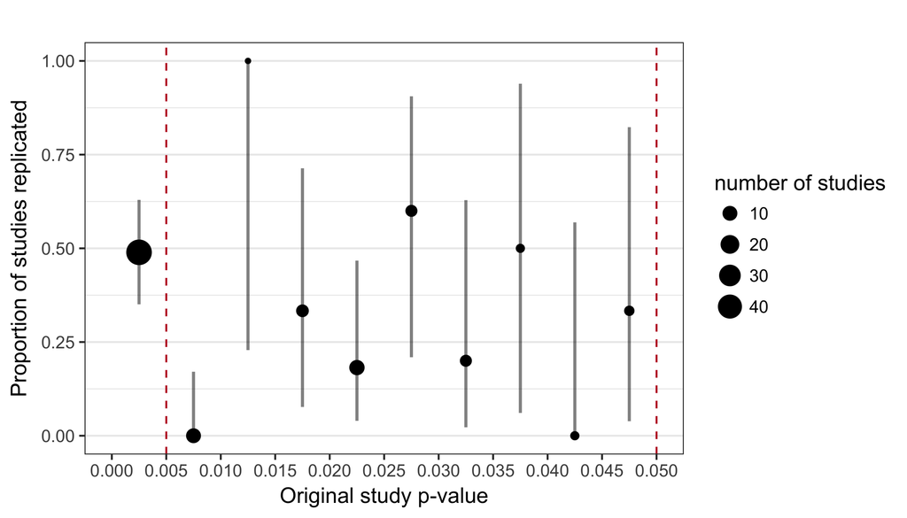

## Research Data Management.

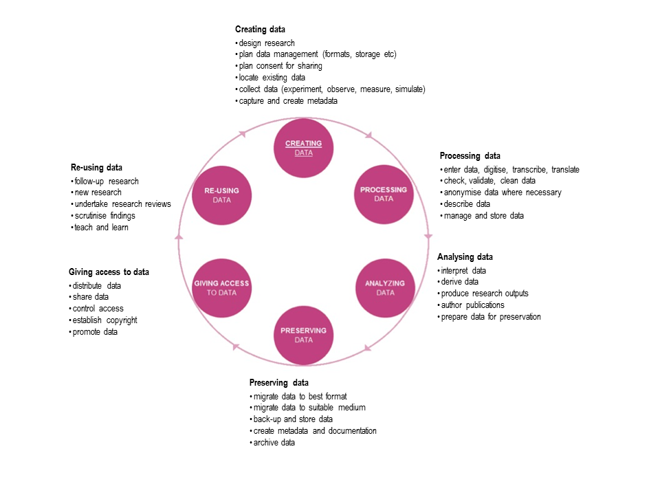

## Research Data Management Resource

- For citizens: Dropbox, GoogleDrive
- For researchers: [OSF](https://osf.io/); [DataWiz](https://datawiz.zpid.de/); [figshare](https://figshare.com/)
- For data specialist: [GitHub](https://github.com/); [GitLab](https://about.gitlab.com/)

## Question for you

How to improve your data management skills in Taiwan? Self-helped researchers; data scientists; Open source NGO …

# What is in Open Science for Libraries?

**Supporters** of Open Access and Open Data ([European Commission, 2012](https://www.fosteropenscience.eu/node/1431#ec2012)).

In open science practices, scitentists have to manage their works [open and reproducible](https://www.fosteropenscience.eu/taxonomy/term/103).

**Enablers** of Open Science Practices: “*Libraries have adapted their role and are now active in the **preservation, curation, publication and dissemination of digital scientific materials**, in the form of publications, data and other research-related content. Libraries and repositories constitute the physical infrastructure that allows scientists to share use and reuse the outcome of their work, and they have been essential in the creation of the Open Science movement”* ([OECD, 2015](https://www.fosteropenscience.eu/node/1431)).

# How libraries can fulfill their role of enablers and have their say?

1. **Advocating and raising awareness**
2. **Giving support to the infrastructures**
3. *Contributing to the development of **research data management (RDM)** policies and strategies at their home institutions and carrying RDM themselves*
4. **Training and supporting researchers**

# What to do next?

## Integrating Information Literacy workshop for PhD candidates

## Key resources and directories of Open Science

- [OKF Open Science Working Group](http://science.okfn.org)
- [Center for Open Science](https://cos.io/)
- [Open Science Grid](https://www.opensciencegrid.org/)
- [Open Science Data Cloud](https://www.opensciencedatacloud.org/)
- [Open Access Directory](http://oad.simmons.edu/oadwiki/Main_Page)
- [Open Science Directory](http://www.opensciencedirectory.net)
- [Open Notebook Science Network](http://onsnetwork.org/)
- [Open Science Federation](http://opensciencefederation.com/)
- [Open Science Framework](https://osf.io/)
- [Science Commons principles for Open Science](http://sciencecommons.org/resources/readingroom/principles-foropen-science/)

## [Check the openness of your research institution and teaching outputs](https://sparceurope.org/what-we-do/open-access/sparc-europe-open-access-resources/open-research-checklist-institutions/)

## [23 Things: Libraries for Research Data](http://www.ands.org.au/working-with-data/skills/23-research-data-things) (Michael Witt, RDA Libraries for Research Data Interest Group)

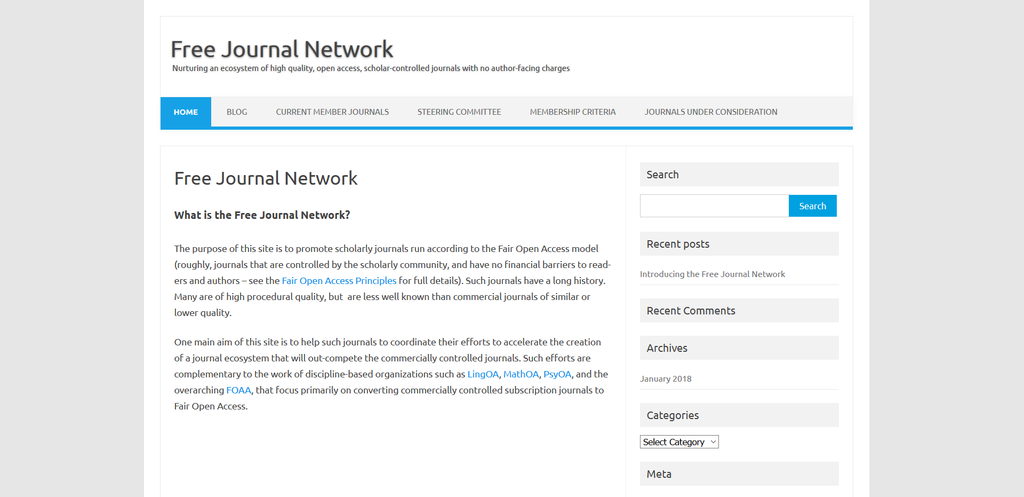

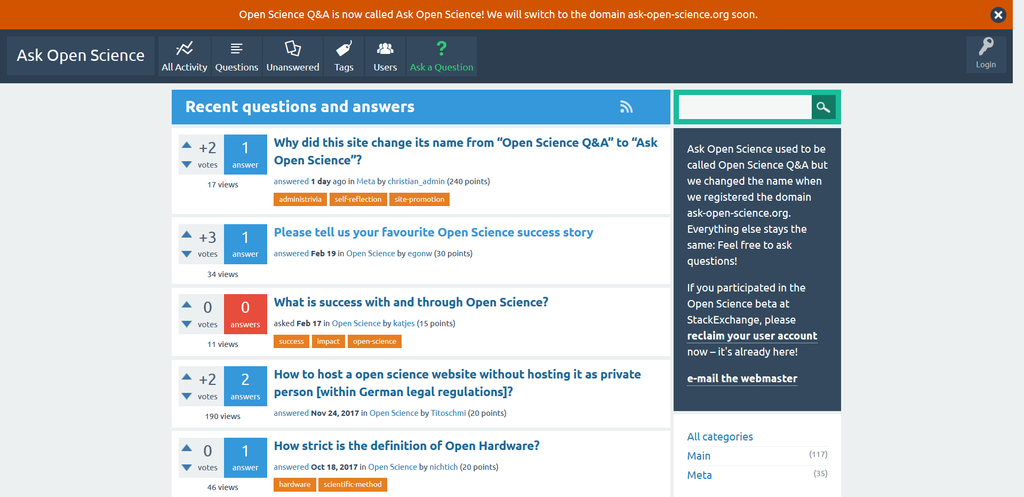